# Introduction to JAGS #2

This tutorial extends the previous tutorial by handling a hierachical model. Just like the previous tutorial, we try to come up with a model that can predict workers’ task completion time. Unlike the previous tutorial, however, we add another assumption that there are two groups of people. One group on average performs the task fast and one group performs the tasks slow.

1. A task duration should be a positive continuos number.
2. A task duration would follow a long-tail distribution with a certain mode and a spread.
3. A task duration depends on the group that the person belongs to. There are two groups; one group performs the task fast and another group performs the task slow.
4. A task duration does not depend on the difficulty of the task.

Let’s first import the libraries and write the above assumptions in JAGS.

```r
data_generation_txt <- '
model {
  for (g in 1:G) {
    for (n in 1:N) {
      duration[g, n] ~ dgamma( shape[g], rate[g] )
    }
  }
  # Parameterizing the above gamma distribution using
  # mode and sd (standard deviation)
  for (g in 1:G) {
    shape[g] <- 1 + mode[g] * rate[g]
    rate[g] <- (mode[g] + sqrt( mode[g]^2 + 4 *sd[g]^2 ) ) / ( 2 * sd[g]^2 )
    sd[g] ~ dunif(0, 100)
    # mode depends on a group.
    mode[g] ~ dgamma( shape_g[g], rate_g[g] )

    # per_group shape and rate
    shape_g[g] <- 1 + mode_g[g] * rate_g[g]
    rate_g[g] <- (mode_g[g] + sqrt( mode_g[g]^2 + 4 * sd_g[g]^2 ) ) / ( 2 * sd_g[g]^2 )

    # mode_g[g] ~ dunif(0, 100)
    # sd_g[g] ~ dunif(0, 100)
  }

}
'
```

```
  for (g in 1:G) {
    for (n in 1:N) {
      duration[g, n] ~ dgamma( shape[g], rate[g] )
    }
  }
```

The duration for each group for a gamma distribution and depend on `shape[g]` and `rate[g]`. We now want to set parameters for these parameters. Let’s see the what follows the above code step-by step.

```
  for (g in 1:G) {
    shape[g] <- 1 + mode[g] * rate[g]
    rate[g] <- (mode[g] + sqrt( mode[g]^2 + 4 *sd[g]^2 ) ) / ( 2 * sd[g]^2 )
    sd[g] ~ dunif(0, 100)
```

The code above shows that we are setting `shape[g]` and `rate[g]` for each group by iterating through `1:G`. Just like we did in the previous tutorial, we are transforming shape and rate into `mode` and standard deviation (`sd`). We set that `sd` follow a uniform distribution (`dunif(0,100)`) to describe our ignorance about the value of `sd`. Now, let’s see how we set `mode[g]`.

```
    # mode depends on a group.
    mode[g] ~ dgamma( shape_g[g], rate_g[g] )

    # per_group shape and rate
    shape_g[g] <- 1 + mode_g[g] * rate_g[g]
    rate_g[g] <- (mode_g[g] + sqrt( mode_g[g]^2 + 4 * sd_g[g]^2 ) ) / ( 2 * sd_g[g]^2 )

    # mode_g[g] ~ dunif(0, 100)
    # sd_g[g] ~ dunif(0, 100)
  }
```

In the above code, we are expressing that `mode[g]` should be a positive value by makeing it follow a gamma distribution with per-group shape (`shape_g`) and per-group rate (`rate_g[g]`). We use the same transformation as above and use `mode_g` and `sd_g` to parameterize the gamma distribution. The lines that are commented out show that `mode_g[g]` and `sd_g[g]` follow a uniform distribution. This is to show our ignorance about the values of these parameters. But because we provide hard-coded values for `mode_g[g]` and `sd_g[g]` in a process of creating synthethic data, we are commenting these out.

Let’s generate data by using parameters `mode_g[1]=10`, `sd_g[1]=1`, `mode_g[2]=50`, and `sd_g[2]=1`. We are using `G=2` and `N=1000` (i.e., there are two groups, and each group has 1,000 people in it).

```r
G <- 2
N <- 1000
mode_g <- c(10, 50)
sd_g <- c(1, 1)
data <- list(
  G=G,
  N=N,
  mode_g=mode_g,
  sd_g=sd_g
)
out <- run.jags(
  data_generation_txt,
  data = data,
  monitor = c("duration"),
  sample = 1,
  n.chains = 1)
```

```
Cannot produce meaningful summary statistics with less than 100 samples
```

[output not shown]

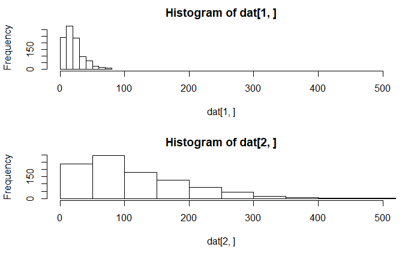

```r
Simulated <- coda::as.mcmc(out)
dat <- as.matrix(Simulated)
dim(dat) <- c(G, N)
par(mfrow=c(2,1))
hist(dat[1,], xlim=c(0,500), breaks=10)
hist(dat[2,], xlim=c(0,500), breaks=10)
```

We have now obtained two sets of synthethic data. Let’s use these data and our model, and check if we can correctly estimate the parameters from the data.

```r
model <-
paste("
model {
  for (g in 1:G) {
    for (n in 1:N) {
      duration[g, n] ~ dgamma( shape[g], rate[g] )
    }
  }
  # Parameterizing the above gamma distribution using
  # mode and sd (standard deviation)
  for (g in 1:G) {
    shape[g] <- 1 + mode[g] * rate[g]
    rate[g] <- (mode[g] + sqrt( mode[g]^2 + 4 *sd[g]^2 ) ) / ( 2 * sd[g]^2 )
    sd[g] ~ dunif(0, 100)
    # mode depends on a group.
    mode[g] ~ dgamma( shape_g[g], rate_g[g] )

    # per_group shape and rate
    shape_g[g] <- 1 + mode_g[g] * rate_g[g]
    rate_g[g] <- (mode_g[g] + sqrt( mode_g[g]^2 + 4 * sd_g[g]^2 ) ) / ( 2 * sd_g[g]^2 )

    mode_g[g] ~ dunif(0, 100)
    sd_g[g] ~ dunif(0, 100)
  }
}
")
model_filename <- "02-jags-intro.jags"
writeLines(model, model_filename)
# Combine the data from the first set and the second set of
# the data generated above
jags.data <- list(
  duration = dat,
  G = G,
  N = N
)
inits <- function(){
  list()
}
# parameters monitored
parameters <- c("shape_g", "rate_g", "mode_g", "sd_g")
# MCMC settings
ni <- 10000
nt <- 6
nb <- 5000
nc <- 2
# call JAGS from R
res <- jags(
  jags.data,
  inits,
  parameters,
  model_filename,
  n.chains = nc,
  n.thin = nt,
  n.iter = ni,
  n.burnin = nb,
  working.directory = getwd())
```

[output not shown]

Let’s see the results.

```r
# summarize posteriors
print(res, digits = 3)
```

```
Inference for Bugs model at "02-jags-intro.jags", fit using jags,
 2 chains, each with 10000 iterations (first 5000 discarded), n.thin = 6
 n.sims = 1666 iterations saved
             mu.vect    sd.vect      2.5%       25%       50%       75%
mode_g[1]     19.167     16.626     0.904     7.699    13.917    26.164
mode_g[2]     45.384     22.773     4.056    29.385    46.299    59.360
rate_g[1]     12.265    329.257     0.012     0.019     0.034     0.099
rate_g[2]     71.248   2594.826     0.012     0.021     0.042     0.134
sd_g[1]       41.576     29.135     1.799    14.786    37.341    64.699
sd_g[2]       43.675     28.179     2.165    19.648    39.997    66.191
shape_g[1]   141.644   3810.484     1.026     1.246     1.650     2.643
shape_g[2]  3597.788 131276.687     1.078     1.751     3.013     7.451
deviance   19144.514      3.006 19140.789 19142.267 19143.916 19145.982
               97.5%  Rhat n.eff
mode_g[1]     65.957 1.005   430
mode_g[2]     92.915 1.002  1600
rate_g[1]      3.435 1.001  1700
rate_g[2]     10.189 1.001  1700
sd_g[1]       96.698 1.001  1700
sd_g[2]       95.468 1.001  1700
shape_g[1]    37.616 1.002  1100
shape_g[2]   488.647 1.001  1600
deviance   19151.711 1.007   790

For each parameter, n.eff is a crude measure of effective sample size,
and Rhat is the potential scale reduction factor (at convergence, Rhat=1).

DIC info (using the rule, pD = var(deviance)/2)
pD = 4.5 and DIC = 19149.0
DIC is an estimate of expected predictive error (lower deviance is better).
```

Let’s see trace plots. They seem to be converging though the estimated modes and standard deviations have large spread.

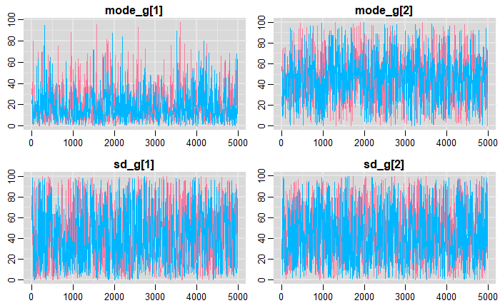

```r
# trace plots
traplot(res, c("mode_g", "sd_g"))
```

The following charts show the estimated parameters. The `mode`s’ peaks are aroudn 10 and 50, which are what we should see (as those are what we set when we made synthethic data). However, the spread is quite big. And we do not have a very good estimates of `sd`s. This is because we used a quite conservative prior (i.e., `dunif(0,100)`).

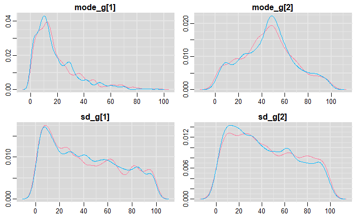

```r
# posterior distributions
denplot(res, c("mode_g", "sd_g"))
```

# Exercise